# Overdispersion in Count Models

Rebecca Gill

2026-05-17

← Back to Index

This page is built in R Markdown. Most code chunks are hidden by default, but you can click ‘show’ to see the code that loads the libraries and generates the data, figures, and tables. The code is also available in my [studycourts/gradData GitHub repository](https://github.com/studycourts/gradData/tree/main/pages).

```r
P <- c(
  "knitr",          # rendering
  "kableExtra",     # table formatting
  "texreg",         # htmlreg() for model tables
  "DHARMa",         # simulation-based residuals; overdispersion and zero tests
  "performance",    # check_overdispersion(), check_zeroinflation()
  "lmtest",         # lrtest() for nested model comparison
  "MASS",           # glm.nb() for negative binomial
  "pscl",           # zeroinfl(), hurdle(), vuong()
  "glmmTMB",        # alternative for ZINB models"
  "patchwork",      # combining ggplots
  "tidyverse"       # wrangling and ggplot2 — load last
)

for (pkg in P) {
  if (!require(pkg, character.only = TRUE)) {
    install.packages(pkg, repos = "http://cran.us.r-project.org")
  }
  library(pkg, character.only = TRUE)
}

rm(P, pkg)  # clean up the mess
```

```r
set.seed(1975)   # for reproducibility

# ── Simulation 1: Well-behaved Poisson data ───────────────────────────────────
# true data-generating process is Poisson; the model should fit well
# used as a baseline to show what "good" looks like

n    <- 800
x1   <- rnorm(n)
x2   <- rbinom(n, 1, 0.4)                        # binary predictor

mu.poi  <- exp(1.2 + 0.6 * x1 - 0.4 * x2)       # true conditional mean
y.poi   <- rpois(n, lambda = mu.poi)             # Poisson counts

poi.df <- data.frame(y = y.poi, x1 = x1, x2 = x2)

# fit the correctly specified Poisson model
poi.mod <- glm(y ~ x1 + x2,
               family    = poisson(link = "log"),
               data      = poi.df,
               na.action = na.omit)

# ── Simulation 2: Overdispersed count data ────────────────────────────────────
# true DGP is negative binomial (theta = 1.5)
# we fit a Poisson to show what overdispersion looks like in diagnostics

mu.nb  <- exp(1.2 + 0.6 * x1 - 0.4 * x2)
y.nb   <- MASS::rnegbin(n, mu = mu.nb, theta = 1.5)  # overdispersed counts

nb.df  <- data.frame(y = y.nb, x1 = x1, x2 = x2)

# misspecified Poisson (wrong family for these data)
poi.wrong <- glm(y ~ x1 + x2,
                 family    = poisson(link = "log"),
                 data      = nb.df,
                 na.action = na.omit)

# correctly specified negative binomial
nb.mod <- MASS::glm.nb(y ~ x1 + x2,
                       data      = nb.df,
                       na.action = na.omit)

# quasipoisson for comparison (estimates dispersion, keeps Poisson structure)
qpoi.mod <- glm(y ~ x1 + x2,
                family    = quasipoisson(link = "log"),
                data      = nb.df,
                na.action = na.omit)

# ── Simulation 3: Zero-inflated data ─────────────────────────────────────────
# two-process DGP: first a binary "structural zero" process, then Poisson counts
# ~30% of observations are structural zeros (e.g., non-participants in a process)

p.zero  <- plogis(-0.8 + 0.5 * x2)               # probability of structural zero
is.zero <- rbinom(n, 1, p.zero)                   # structural zero indicator

mu.zip  <- exp(0.9 + 0.7 * x1)                   # Poisson mean for non-zero process
y.count <- rpois(n, lambda = mu.zip)              # Poisson counts
y.zip   <- ifelse(is.zero == 1, 0, y.count)       # apply structural zeros

zip.df  <- data.frame(y = y.zip, x1 = x1, x2 = x2)

# misspecified Poisson on ZIP data
poi.zip.wrong <- glm(y ~ x1 + x2,
                     family    = poisson(link = "log"),
                     data      = zip.df,
                     na.action = na.omit)

# correctly specified ZIP model
zip.mod <- pscl::zeroinfl(
  y ~ x1 + x2 | x2,        # count process | zero-inflation process
  dist = "poisson",
  data = zip.df
)

# sim 4: overdispersed AND zero-inflated data (ZINB)

p.zero.nb  <- plogis(-0.6 + 0.4 * x2)
is.zero.nb <- rbinom(n, 1, p.zero.nb)
mu.zinb    <- exp(1.0 + 0.6 * x1)
y.nb.raw   <- MASS::rnegbin(n, mu = mu.zinb, theta = 2)
y.zinb     <- ifelse(is.zero.nb == 1, 0, y.nb.raw)

zinb.df  <- data.frame(y = y.zinb, x1 = x1, x2 = x2)

# correctly specified ZINB
zinb.mod <- pscl::zeroinfl(
  y ~ x1 + x2 | x2,
  dist = "negbin",
  data = zinb.df
)

# NB model for comparison (handles overdispersion but not zero inflation)
nb.zinb.wrong <- MASS::glm.nb(y ~ x1 + x2, data = zinb.df)
```

## Introduction

Count data — the number of times something happened — are everywhere in political science. Bills introduced in a legislature. Protest events in a country-year. Conflict events in a region. Doctor visits in a survey year. The natural starting point for all of these is the Poisson model, which assumes that the variance of the outcome equals its mean: $\text{Var}(Y) = E(Y) = \mu$.

Real count data almost never cooperate with this assumption. The variance is almost always larger than the mean — sometimes much larger. This is **overdispersion**, and ignoring it has a specific and unpleasant consequence: the Poisson model will underestimate standard errors, making your predictors look more precisely estimated than they really are. In a field that already has a fraught relationship with $p$-values and significance thresholds, this is not a small problem.

A related but distinct issue is **excess zeros**: more observations with a count of zero than the fitted model predicts, even after accounting for the mean structure. This often arises because some units in the sample can’t or wouldn’t experience the event under any circumstances — they’re zeroes for structural reasons, not just because their Poisson rate happened to be low.

This page works through both problems systematically. We start with the basics of the equidispersion assumption and what it looks like when it fails, move through the tools for detecting each problem, and end with a decision framework for choosing among the family of count models.

## The Equidispersion Assumption

The Poisson distribution is characterized by a single parameter $\lambda$ (or $\mu$ in regression notation) that serves as both the conditional mean and the conditional variance:

$$E(Y \mid \mathbf{x}) = \text{Var}(Y \mid \mathbf{x}) = \mu$$

This equidispersion property is elegant but restrictive. It says that if your model predicts, on average, 3 events for a given covariate pattern, then the variance of the count for that covariate pattern should also be 3. For data generated by a pure Poisson process — radioactive decay, random arrivals in a queue — this is exactly right. For social and political phenomena, it almost never is.

The most direct way to see this in your data is to compare the sample mean and variance of the count variable before you even fit a model:

```r
# compare mean and variance — if roughly equal, Poisson is plausible
cat("=== Well-behaved Poisson data ===\n")
```

```
## === Well-behaved Poisson data ===
```

```r
cat("Mean:    ", round(mean(poi.df$y), 3), "\n")
```

```
## Mean:     3.426
```

```r
cat("Variance:", round(var(poi.df$y),  3), "\n")
```

```
## Variance: 10.05
```

```r
cat("Ratio:   ", round(var(poi.df$y) / mean(poi.df$y), 3), "\n\n")
```

```
## Ratio:    2.933
```

```r
cat("=== Overdispersed NB data ===\n")
```

```
## === Overdispersed NB data ===
```

```r
cat("Mean:    ", round(mean(nb.df$y), 3), "\n")
```

```
## Mean:     3.636
```

```r
cat("Variance:", round(var(nb.df$y),  3), "\n")
```

```
## Variance: 31.35
```

```r
cat("Ratio:   ", round(var(nb.df$y) / mean(nb.df$y), 3), "\n")
```

```
## Ratio:    8.622
```

A variance-to-mean ratio near 1 is consistent with equidispersion. Ratios substantially greater than 1 signal overdispersion. This is a quick first check, not a formal test — it doesn’t condition on the covariates, so it can be misleading if the mean is highly variable across observations. But it’s a useful starting point.

## Detecting Overdispersion

### After Fitting: The QuasiPoisson Approach

The cleanest post-estimation check for overdispersion is to refit the model using the `quasipoisson` family, which relaxes the equidispersion constraint by estimating a dispersion parameter $\phi$ from the data:

$$\text{Var}(Y \mid \mathbf{x}) = \phi \cdot \mu$$

If $\phi = 1$, the data are equidispersed and the standard Poisson is appropriate. If $\phi > 1$, the data are overdispersed. The estimated $\phi$ is reported as the “(Estimated) dispersion parameter” in the `summary()` output:

```r
# quasipoisson on well-behaved data: phi should be near 1
cat("=== QuasiPoisson on Poisson data ===\n")
```

```
## === QuasiPoisson on Poisson data ===
```

```r
summary(glm(y ~ x1 + x2,
            family = quasipoisson,
            data   = poi.df))$dispersion
```

```
## [1] 0.9817
```

```r
# quasipoisson on overdispersed data: phi should be >> 1
cat("\n=== QuasiPoisson on NB data ===\n")
```

```
##
## === QuasiPoisson on NB data ===
```

```r
summary(qpoi.mod)$dispersion
```

```
## [1] 3.702
```

A dispersion parameter of, say, 4.2 means the actual variance in the data is about 4.2 times what the Poisson model predicts. Standard errors from the Poisson model will be off by a factor of $\sqrt{4.2} \approx 2.0$ — every $p$-value and confidence interval is wrong.

### The `performance` Approach

`performance::check_overdispersion()` provides a formal test based on the ratio of the Pearson $\chi^2$ statistic to its degrees of freedom:

```r
# formal overdispersion test
cat("=== Poisson data ===\n")
```

```
## === Poisson data ===
```

```r
performance::check_overdispersion(poi.mod)
```

```
## # Overdispersion test
##
##        dispersion ratio =   0.982
##   Pearson's Chi-Squared = 782.412
##                 p-value =   0.637
```

```r
cat("\n=== NB data fit with Poisson ===\n")
```

```
##
## === NB data fit with Poisson ===
```

```r
performance::check_overdispersion(poi.wrong)
```

```
## # Overdispersion test
##
##        dispersion ratio =    3.702
##   Pearson's Chi-Squared = 2950.419
##                 p-value =  < 0.001
```

The test statistic is the **Pearson dispersion statistic** $\hat{\phi} = \chi^2_P / (n - k)$, where $\chi^2_P = \sum (y_i - \hat{\mu}_i)^2 / \hat{\mu}_i$ is the sum of squared Pearson residuals. Under the null of equidispersion, this should be approximately 1. A significant result confirms overdispersion.

### DHARMa: Simulation-Based Dispersion Test

DHARMa’s `testDispersion()` provides a complementary simulation-based test. It compares the variance of the observed data to the variance of datasets simulated from the fitted model, asking whether the observed variance is unusually large relative to what the model predicts:

Figure 1: DHARMa dispersion test for the Poisson model fitted to overdispersed data. The red line marks the observed standard deviation; the histogram shows the distribution of standard deviations from data simulated under the fitted model. The observed value falls far to the right of the simulated distribution — strong evidence of overdispersion.

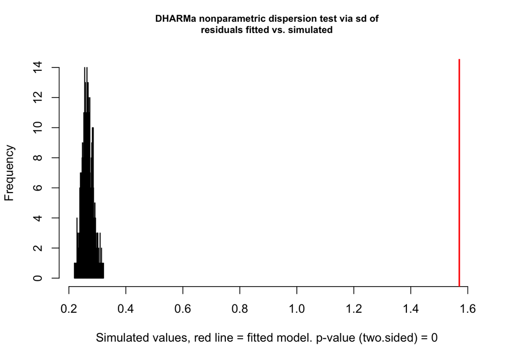

```
##
##  DHARMa nonparametric dispersion test via sd of residuals fitted vs.
##  simulated
##
## data:  simulationOutput
## dispersion = 5.9, p-value <0.0000000000000002
## alternative hypothesis: two.sided
```

```r
sim.wrong <- DHARMa::simulateResiduals(poi.wrong, n = 500, plot = FALSE)

DHARMa::testDispersion(sim.wrong, plot = TRUE)
```

The histogram of simulated dispersion values should surround the observed value (red line) if the model is correctly specified. When the observed value sits in the tail of the histogram, the model is systematically underpredicting variance.

I ran all three overdispersion tests and they all say the data are overdispersed. Do I need to report all of them?

No — one well-chosen test is enough to establish the point. In practice, the `performance::check_overdispersion()` result (which gives you a test statistic and a $p$-value) is the most compact and conventional way to report it. Mention the quasiPoisson dispersion estimate alongside it to give readers a sense of the scale of the problem. The DHARMa plot is most useful for your own understanding and for presentations where a visual makes the issue vivid — you don’t necessarily need to include it in a paper.

## Responding to Overdispersion

### Option 1: The QuasiPoisson Model

The quasipoisson model corrects standard errors for overdispersion without changing the coefficient estimates. It multiplies all standard errors by $\sqrt{\hat{\phi}}$, which widens confidence intervals and increases $p$-values appropriately. Coefficients are identical to the standard Poisson.

This is a pragmatic fix rather than a proper probabilistic model — the quasipoisson doesn’t have a likelihood, which means you can’t use AIC, BIC, or likelihood ratio tests to compare it to other models. Use it when you want a quick correction and don’t need formal model comparison.

```r
# side by side: Poisson (wrong) vs. QuasiPoisson (corrected SEs)
# notice: identical coefficients, wider SEs in QuasiPoisson
texreg::htmlreg(
  list(poi.wrong, qpoi.mod),
  custom.model.names = c("Poisson (wrong)", "QuasiPoisson"),
  caption     = "Poisson vs. QuasiPoisson: coefficients are identical; standard errors differ",
  caption.above = TRUE,
  single.row  = TRUE,
  stars       = c(0.001, 0.01, 0.05)
)
```

Poisson vs. QuasiPoisson: coefficients are identical; standard errors differ

|  | Poisson (wrong) | QuasiPoisson |
| --- | --- | --- |
| (Intercept) | 1.23 (0.03)*** | 1.23 (0.05)*** |
| x1 | 0.69 (0.02)*** | 0.69 (0.03)*** |
| x2 | -0.51 (0.04)*** | -0.51 (0.08)*** |
| AIC | 4514.48 |  |
| BIC | 4528.54 |  |
| Log Likelihood | -2254.24 |  |
| Deviance | 2663.15 | 2663.15 |
| Num. obs. | 800 | 800 |

***p < 0.001; **p < 0.01; *p < 0.05

### Option 2: The Negative Binomial Model

The negative binomial model is the standard probabilistic solution to overdispersion. It adds a dispersion parameter $\theta$ (sometimes called the precision parameter) that allows the variance to exceed the mean:

$$\text{Var}(Y \mid \mathbf{x}) = \mu + \frac{\mu^2}{\theta}$$

When $\theta \rightarrow \infty$, the NB collapses to the Poisson (no overdispersion). Smaller $\theta$ means more overdispersion relative to Poisson. Because the NB has a proper likelihood, it supports AIC/BIC comparisons and likelihood ratio tests.

```r
# Poisson vs. NB on overdispersed data
texreg::htmlreg(
  list(poi.wrong, nb.mod),
  custom.model.names = c("Poisson (misspecified)", "Negative Binomial"),
  caption     = "Poisson vs. Negative Binomial on overdispersed count data",
  caption.above = TRUE,
  single.row  = TRUE,
  stars       = c(0.001, 0.01, 0.05)
)
```

Poisson vs. Negative Binomial on overdispersed count data

|  | Poisson (misspecified) | Negative Binomial |
| --- | --- | --- |
| (Intercept) | 1.23 (0.03)*** | 1.20 (0.05)*** |
| x1 | 0.69 (0.02)*** | 0.67 (0.04)*** |
| x2 | -0.51 (0.04)*** | -0.43 (0.08)*** |
| AIC | 4514.48 | 3527.47 |
| BIC | 4528.54 | 3546.21 |
| Log Likelihood | -2254.24 | -1759.73 |
| Deviance | 2663.15 | 883.66 |
| Num. obs. | 800 | 800 |

***p < 0.001; **p < 0.01; *p < 0.05

```r
# confirm: NB fits significantly better than Poisson
# (note: lrtest() requires both models to have likelihoods — not valid for quasipoisson)
lmtest::lrtest(poi.wrong, nb.mod)
```

```
## Likelihood ratio test
##
## Model 1: y ~ x1 + x2
## Model 2: y ~ x1 + x2
##   #Df LogLik Df Chisq          Pr(>Chisq)
## 1   3  -2254
## 2   4  -1760  1   989 <0.0000000000000002 ***
## ---
## Signif. codes:  0 '***' 0.001 '**' 0.01 '*' 0.05 '.' 0.1 ' ' 1
```

```r
# look at the estimated theta (precision) parameter
cat("Estimated theta:", round(nb.mod$theta, 3), "\n")
```

```
## Estimated theta: 1.436
```

```r
cat("SE of theta:    ", round(nb.mod$SE.theta, 3), "\n")
```

```
## SE of theta:     0.117
```

A $\theta$ estimate of around 1.5 is consistent with how we generated these data ($\theta = 1.5$ in the simulation). Smaller $\theta$ values indicate more severe overdispersion.

The LRT comparing Poisson to NB should be overwhelmingly significant here — the two models are nested (Poisson is NB with $\theta \rightarrow \infty$), and the data were genuinely generated by an NB process.

## Detecting Excess Zeros

Overdispersion and excess zeros are distinct problems that can occur independently or together. Overdispersion is about the overall variance being too large; excess zeros are about there being more zero counts specifically than the model predicts. You can have overdispersion without excess zeros (just a fat-tailed count distribution), and you can have excess zeros without much general overdispersion (if the count process for non-zero observations is well-behaved).

### Visual Check First

The most informative first step is to compare the observed distribution of counts to the model’s predicted distribution:

```r
# compute observed zero fraction and model-predicted zero fractions
obs.zero.poi <- mean(poi.df$y == 0)
obs.zero.zip <- mean(zip.df$y == 0)

# Poisson predicted zero fraction: P(Y=0) = exp(-mu)
pred.zero.poi.on.poi <- mean(exp(-predict(poi.mod, type = "response")))
pred.zero.poi.on.zip <- mean(exp(-predict(poi.zip.wrong, type = "response")))

# ZIP predicted zero fraction: structural zeros + Poisson zeros
zip.pred.prob <- predict(zip.mod, type = "prob")[, 1]
pred.zero.zip <- mean(zip.pred.prob)

zero.compare <- data.frame(
  Dataset = c("Poisson data", "ZIP data"),
  Observed   = round(c(obs.zero.poi, obs.zero.zip), 3),
  Pred_Poisson = round(c(pred.zero.poi.on.poi, pred.zero.poi.on.zip), 3),
  Pred_ZIP   = c(NA, round(pred.zero.zip, 3))
)

kable(zero.compare,
      col.names = c("Dataset", "Observed % zeros",
                    "Poisson predicted % zeros", "ZIP predicted % zeros"),
      caption   = "Observed vs. predicted proportion of zeros",
      na        = "—") %>%
  kable_styling(bootstrap_options = c("striped", "hover"),
                full_width = FALSE)
```

Table 1: Table 2: Observed vs. predicted proportion of zeros

| Dataset | Observed % zeros | Poisson predicted % zeros | ZIP predicted % zeros |
| --- | --- | --- | --- |
| Poisson data | 0.099 | 0.113 |  |
| ZIP data | 0.429 | 0.246 | 0.435 |

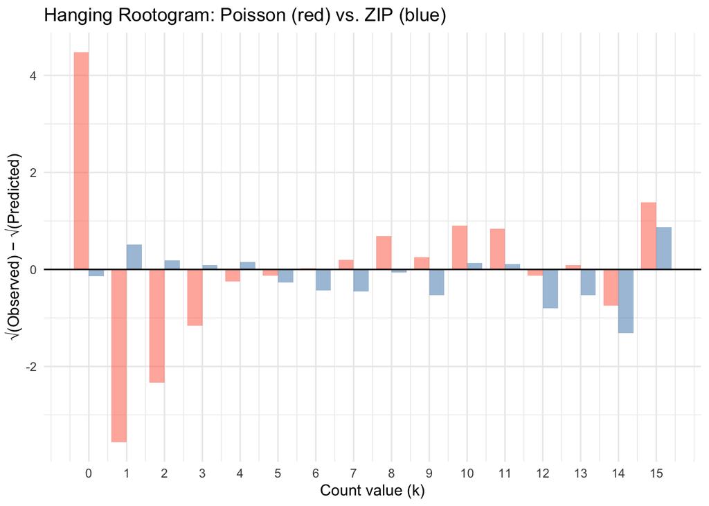

```r
# hanging rootogram: a specialized plot for count data fit
# the bars hang from the fitted curve; bars below the x-axis = underprediction

# observed counts
obs.counts <- table(factor(zip.df$y, levels = 0:max(zip.df$y)))
obs.k      <- as.integer(names(obs.counts))

# Poisson predicted counts
poi.lambda <- predict(poi.zip.wrong, type = "response")
poi.pred   <- sapply(obs.k, function(k) sum(dpois(k, poi.lambda)))

# ZIP predicted counts
zip.probs  <- predict(zip.mod, type = "prob")
zip.pred   <- sapply(obs.k, function(k) {
  j <- k + 1  # column index (zero-indexed counts)
  if (j <= ncol(zip.probs)) sum(zip.probs[, j]) else 0
})

# rootogram data
rg.df <- data.frame(
  k         = obs.k,
  obs       = as.numeric(obs.counts),
  poi.pred  = poi.pred,
  zip.pred  = zip.pred
) %>%
  mutate(
    sqrt.obs      = sqrt(obs),
    sqrt.poi.pred = sqrt(poi.pred),
    sqrt.zip.pred = sqrt(zip.pred),
    hang.poi      = sqrt.obs - sqrt.poi.pred,
    hang.zip      = sqrt.obs - sqrt.zip.pred
  ) %>%
  filter(k <= 15)   # trim to first 15 counts for readability

ggplot(rg.df, aes(x = k)) +
  geom_col(aes(y = hang.poi), fill = "tomato", alpha = 0.5, width = 0.4,
           position = position_nudge(x = -0.2)) +
  geom_col(aes(y = hang.zip), fill = "steelblue", alpha = 0.5, width = 0.4,
           position = position_nudge(x =  0.2)) +
  geom_hline(yintercept = 0, color = "black") +
  scale_x_continuous(breaks = 0:15) +
  labs(x     = "Count value (k)",
       y     = "√(Observed) − √(Predicted)",
       title = "Hanging Rootogram: Poisson (red) vs. ZIP (blue)") +
  theme_minimal()
```

### Formal Tests

`performance::check_zeroinflation()` provides a formal test based on comparing the observed number of zeros to the model’s predicted number:

```r
# formal zero-inflation test
cat("=== Poisson model on Poisson data (no excess zeros) ===\n")
```

```
## === Poisson model on Poisson data (no excess zeros) ===
```

```r
performance::check_zeroinflation(poi.mod)
```

[output not shown]

```r
cat("\n=== Poisson model on ZIP data (excess zeros) ===\n")
```

```
##
## === Poisson model on ZIP data (excess zeros) ===
```

```r
performance::check_zeroinflation(poi.zip.wrong)
```

[output not shown]

DHARMa’s `testZeroInflation()` provides a simulation-based version:

Figure 3: DHARMa zero-inflation test for the Poisson model on zero-inflated data. The red vertical line marks the observed number of zeros; the histogram shows the distribution of zero counts across simulated datasets. The observed value sits far to the right — more zeros than the model can account for.

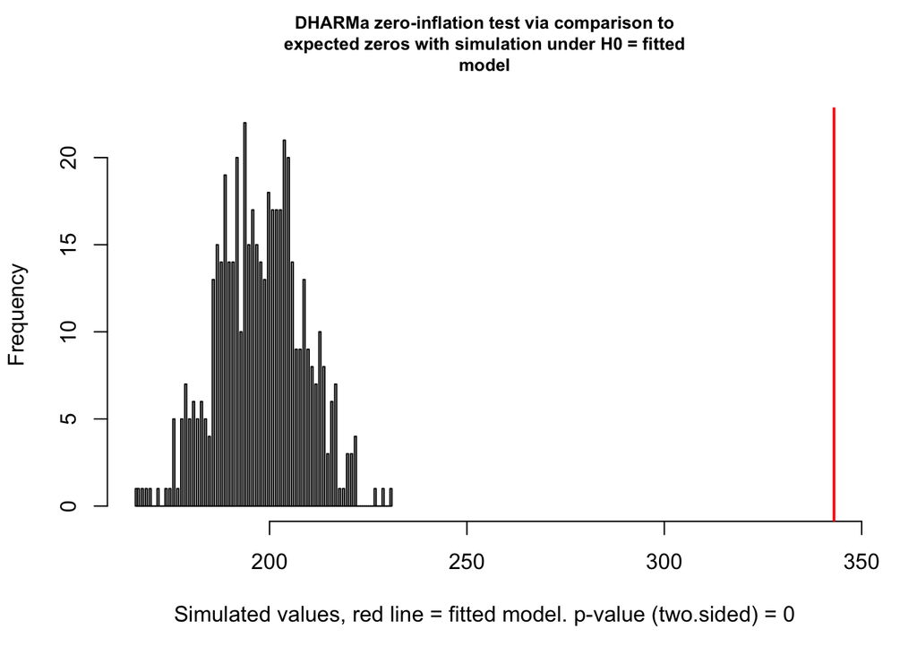

```
##
##  DHARMa zero-inflation test via comparison to expected zeros with
##  simulation under H0 = fitted model
##
## data:  simulationOutput
## ratioObsSim = 1.7, p-value <0.0000000000000002
## alternative hypothesis: two.sided
```

```r
sim.zip.wrong <- DHARMa::simulateResiduals(poi.zip.wrong, n = 500, plot = FALSE)
DHARMa::testZeroInflation(sim.zip.wrong, plot = TRUE)
```

## Responding to Excess Zeros

When you’ve confirmed that your data have more zeros than the count model predicts, you have two main modeling frameworks to choose from. They embody different theoretical assumptions about where the zeros are coming from.

### Zero-Inflated Models

Zero-inflated models assume there are two types of observations in the data:

- **Structural zeros**: units that would always produce a zero, regardless of the predictor values — they’re “always-zero” cases. Maybe they don’t participate in the process at all.
- **Sampling zeros**: units that could in principle produce a non-zero count but happened to produce zero in this observation period because their rate is low.

The zero-inflated model estimates two processes simultaneously: a binary model for the probability of being a structural zero, and a count model (Poisson or NB) for the non-structural-zero cases. The probability of observing $Y = 0$ is:

$$P(Y = 0) = \pi + (1 - \pi) \cdot P_{\text{count}}(Y = 0 \mid \mu)$$

where $\pi$ is the probability of being a structural zero and $P_{\text{count}}(Y = 0 \mid \mu) = e^{-\mu}$ for the Poisson.

```r
# ZIP model: Poisson count process, binary zero-inflation process
# formula: count process | zero-inflation process
# here: count process depends on x1; inflation process depends on x2
zip.fit <- pscl::zeroinfl(
  y ~ x1 | x2,
  dist = "poisson",
  data = zip.df
)

summary(zip.fit)
```

```
##
## Call:
## pscl::zeroinfl(formula = y ~ x1 | x2, data = zip.df, dist = "poisson")
##
## Pearson residuals:
##    Min     1Q Median     3Q    Max
## -1.343 -0.848 -0.172  0.667  4.545
##
## Count model coefficients (poisson with log link):
##             Estimate Std. Error z value            Pr(>|z|)
## (Intercept)   0.8773     0.0338    25.9 <0.0000000000000002 ***
## x1            0.7174     0.0250    28.7 <0.0000000000000002 ***
##
## Zero-inflation model coefficients (binomial with logit link):
##             Estimate Std. Error z value       Pr(>|z|)
## (Intercept)   -0.793      0.121   -6.56 0.000000000053 ***
## x2             0.236      0.177    1.33           0.18
## ---
## Signif. codes:  0 '***' 0.001 '**' 0.01 '*' 0.05 '.' 0.1 ' ' 1
##
## Number of iterations in BFGS optimization: 9
## Log-likelihood: -1.31e+03 on 4 Df
```

The output has two sections: the count model (log-linear, same interpretation as Poisson) and the zero-inflation model (logit, giving the log-odds of being a structural zero). A positive coefficient in the zero-inflation model means the predictor *increases* the probability of being in the “always-zero” group.

### Hurdle Models

Hurdle models take a different structural position. They assume:

1. A binary process determines whether the count is zero or positive.
2. Conditional on being positive, a truncated count model (Poisson or NB truncated at zero) determines the magnitude.

The key conceptual difference from the zero-inflated model is that in the hurdle model, *all* zeros come from the binary process — there’s no mixing of structural and sampling zeros. The zero-inflation model allows sampling zeros to appear in both the binary and count components; the hurdle model draws a hard line.

```r
# hurdle model: binary process for zero vs. non-zero,
# truncated Poisson for the positive counts
hurdle.fit <- pscl::hurdle(
  y ~ x1 | x2,
  dist  = "poisson",
  zero.dist = "binomial",
  data  = zip.df
)

summary(hurdle.fit)
```

```
##
## Call:
## pscl::hurdle(formula = y ~ x1 | x2, data = zip.df, dist = "poisson",
##     zero.dist = "binomial")
##
## Pearson residuals:
##    Min     1Q Median     3Q    Max
## -1.139 -0.912 -0.122  0.712  4.751
##
## Count model coefficients (truncated poisson with log link):
##             Estimate Std. Error z value            Pr(>|z|)
## (Intercept)   0.8506     0.0371    22.9 <0.0000000000000002 ***
## x1            0.7367     0.0271    27.2 <0.0000000000000002 ***
## Zero hurdle model coefficients (binomial with logit link):
##             Estimate Std. Error z value Pr(>|z|)
## (Intercept)    0.359      0.094    3.82  0.00013 ***
## x2            -0.172      0.145   -1.19  0.23334
## ---
## Signif. codes:  0 '***' 0.001 '**' 0.01 '*' 0.05 '.' 0.1 ' ' 1
##
## Number of iterations in BFGS optimization: 8
## Log-likelihood: -1.32e+03 on 4 Df
```

How do I decide between a ZIP and a hurdle model? They both seem to fit excess zeros.

The decision is primarily theoretical, not statistical. Ask yourself: does it make conceptual sense for some units to be structurally incapable of the outcome? If yes, zero-inflation is the right framing. If the distinction between “structural zeros” and “sampling zeros” doesn’t map onto anything meaningful in your application, a hurdle model’s cleaner two-part structure (zero vs. positive, then how many) is often more interpretable.

The Vuong test can provide some empirical guidance — it compares the log-likelihoods of the two models on an observation-by-observation basis:

```r
# Vuong test: positive statistic favors ZIP; negative favors hurdle
# (both are compared against the standard Poisson here)
pscl::vuong(zip.fit, hurdle.fit)
```

```
## Vuong Non-Nested Hypothesis Test-Statistic:
## (test-statistic is asymptotically distributed N(0,1) under the
##  null that the models are indistinguishible)
## -------------------------------------------------------------
##               Vuong z-statistic             H_A p-value
## Raw                         1.4 model1 > model2   0.081
## AIC-corrected               1.4 model1 > model2   0.081
## BIC-corrected               1.4 model1 > model2   0.081
```

Treat the Vuong test as one piece of evidence, not a decision rule. A non-significant result doesn’t mean the models are equivalent — it means the data don’t strongly discriminate between them, which is itself useful information.

### When Both Problems Are Present: ZINB

When the data are both overdispersed *and* zero-inflated, the zero-inflated negative binomial (ZINB) is the appropriate model. It combines the NB count process (which handles overdispersion) with the zero-inflation binary component:

```r
# ZINB: NB count process with zero-inflation
zinb.fit <- pscl::zeroinfl(
  y ~ x1 | x2,
  dist = "negbin",
  data = zinb.df
)

# compare NB (handles overdispersion only) to ZINB (handles both)
lmtest::lrtest(nb.zinb.wrong, zinb.fit)
```

```
## Likelihood ratio test
##
## Model 1: y ~ x1 + x2
## Model 2: y ~ x1 | x2
##   #Df LogLik Df Chisq          Pr(>Chisq)
## 1   4  -1417
## 2   5  -1377  1  81.2 <0.0000000000000002 ***
## ---
## Signif. codes:  0 '***' 0.001 '**' 0.01 '*' 0.05 '.' 0.1 ' ' 1
```

The LRT comparing NB to ZINB tests whether the zero-inflation component is needed on top of the negative binomial’s natural accommodation of overdispersion. A significant result means the extra zeros can’t be fully explained by the NB’s fat tail.

## Checking the Final Model

Once you’ve chosen and fitted your count model, run the standard diagnostic checks to confirm the fit is adequate. DHARMa handles all count model types — Poisson, NB, ZIP, ZINB, and hurdle — via the same `simulateResiduals()` workflow:

Figure 4: DHARMa residuals for the ZIP model on zero-inflated data.

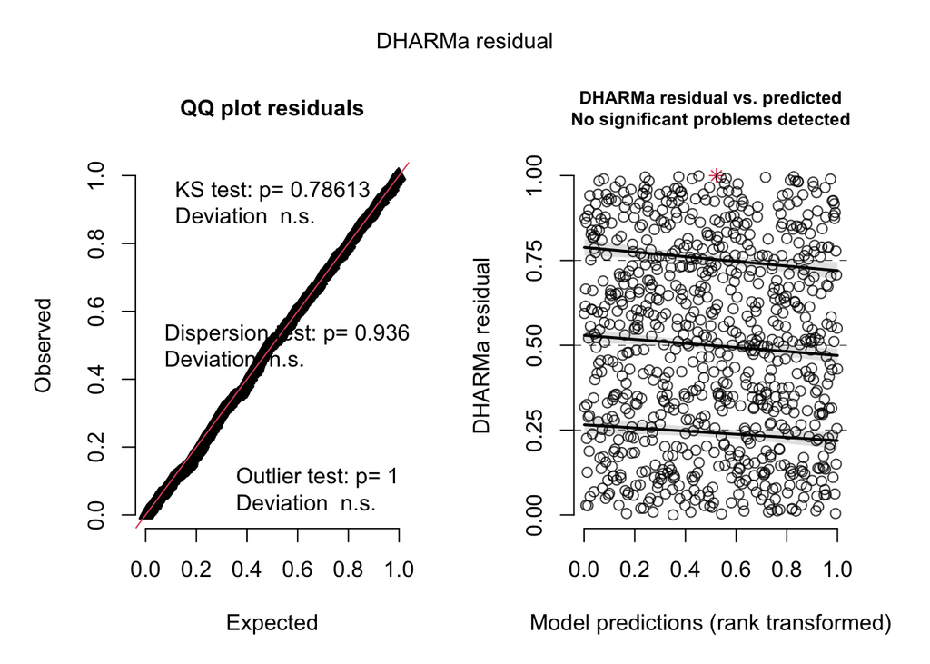

```r
# DHARMa residuals for the ZIP model

# re-run using glmmTMB for better compatibility with DHARMa

zip.tmb <- glmmTMB(
  y ~ x1,                # Count model (before the | in pscl)
  ziformula = ~ x2,      # Zero-inflation model (after the | in pscl)
  family = poisson,      # Distribution
  data = zip.df
)

sim.zip <- DHARMa::simulateResiduals(zip.tmb, n = 500, plot = FALSE)
plot(sim.zip)
```

Both the QQ plot (left) and the residual-vs-fitted plot (right) should look clean under a correctly specified model. If you see patterns in the residuals, you may need to revisit your model choice or consider additional covariates or random effects. Let’s check the formal tests next.

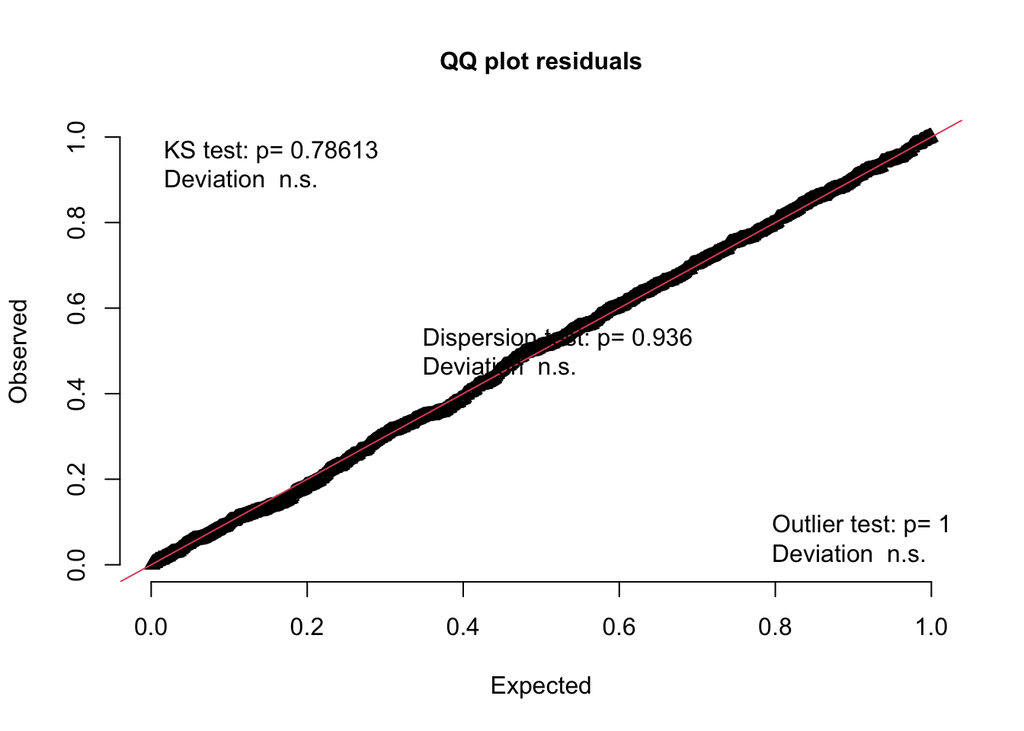

```
##
##  Asymptotic one-sample Kolmogorov-Smirnov test
##
## data:  simulationOutput$scaledResiduals
## D = 0.023, p-value = 0.8
## alternative hypothesis: two-sided
```

```r
# formal tests for the ZIP model
DHARMa::testUniformity(sim.zip)
```

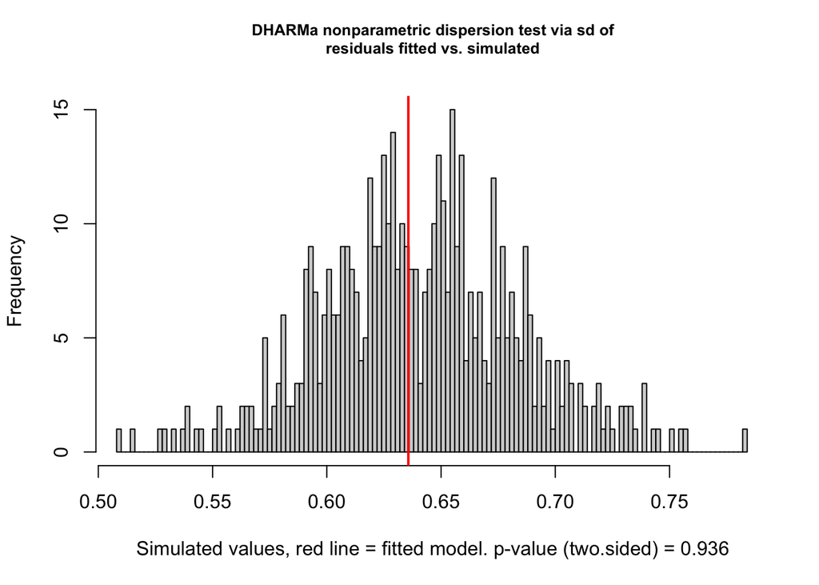

```
##
##  DHARMa nonparametric dispersion test via sd of residuals fitted vs.
##  simulated
##
## data:  simulationOutput
## dispersion = 0.99, p-value = 0.9
## alternative hypothesis: two.sided
```

```r
DHARMa::testDispersion(sim.zip)
```

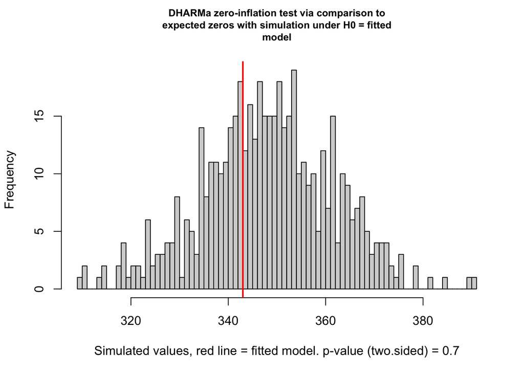

```
##
##  DHARMa zero-inflation test via comparison to expected zeros with
##  simulation under H0 = fitted model
##
## data:  simulationOutput
## ratioObsSim = 0.98, p-value = 0.7
## alternative hypothesis: two.sided
```

```r
DHARMa::testZeroInflation(sim.zip)
```

After fitting the correct model, all three tests should be non-significant: the residuals should be uniform, the dispersion should be consistent with the model, and the zero counts should match the model’s predictions.

## The Count Model Decision Tree

Here is a practical summary of the model selection process for count data:

```r
dec.tbl <- data.frame(
  Step = c(
    "1. Fit Poisson; check overdispersion",
    "1a. Overdispersion confirmed",
    "1b. No overdispersion",
    "2. Check for excess zeros (on Poisson or NB)",
    "2a. Excess zeros + no overdispersion",
    "2b. Excess zeros + overdispersion",
    "2c. No excess zeros + no overdispersion",
    "2d. No excess zeros + overdispersion",
    "3. Choose ZIP vs. hurdle",
    "4. Confirm final model with DHARMa"
  ),
  Action = c(
    "`performance::check_overdispersion()` or `testDispersion()`",
    "Switch to NB (`MASS::glm.nb()`); compare with LRT",
    "Keep Poisson (but check for zero inflation)",
    "`performance::check_zeroinflation()` or `testZeroInflation()`",
    "Zero-inflated Poisson (ZIP) or Poisson hurdle (`pscl`)",
    "Zero-inflated NB (ZINB) or NB hurdle (`pscl`)",
    "Poisson is adequate",
    "Negative binomial is adequate",
    "Theoretical: are structural zeros plausible? If yes: ZIP/ZINB. If no: hurdle.",
    "`simulateResiduals()` + `plot()` + all three `test*()` functions"
  )
)

kable(dec.tbl,
      col.names = c("Step", "Action / Model"),
      caption   = "Count model selection: a step-by-step decision guide") %>%
  kable_styling(bootstrap_options = c("striped", "hover"),
                full_width = FALSE) %>%
  column_spec(1, bold = TRUE)
```

Table 3: Table 4: Count model selection: a step-by-step decision guide

Step

Action / Model

1. Fit Poisson; check overdispersion

`performance::check_overdispersion()` or `testDispersion()`

1a. Overdispersion confirmed

Switch to NB (`MASS::glm.nb()`); compare with LRT

1b. No overdispersion

Keep Poisson (but check for zero inflation)

2. Check for excess zeros (on Poisson or NB)

`performance::check_zeroinflation()` or `testZeroInflation()`

2a. Excess zeros + no overdispersion

Zero-inflated Poisson (ZIP) or Poisson hurdle (`pscl`)

2b. Excess zeros + overdispersion

Zero-inflated NB (ZINB) or NB hurdle (`pscl`)

2c. No excess zeros + no overdispersion

Poisson is adequate

2d. No excess zeros + overdispersion

Negative binomial is adequate

3. Choose ZIP vs. hurdle

Theoretical: are structural zeros plausible? If yes: ZIP/ZINB. If no: hurdle.

4. Confirm final model with DHARMa

`simulateResiduals()` + `plot()` + all three `test*()` functions

One thing worth stating plainly: model selection in count data is iterative. Diagnosing overdispersion, then excess zeros, then checking the final model — and potentially looping back if the final model still doesn’t fit — is the process, not a sign that you’re doing something wrong. DHARMa’s `testZeroInflation()` and `testDispersion()` on the final model are your best guide to whether you’ve arrived at an adequate specification.